# Regression Analysis on House Prices

### Hyperparameter Tuning

We will use GridSearch to tune the parameters in the XGBoost

```python
parameter_tuning= {
    'colsample_bytree':[0.4,0.6,0.8],
    'gamma':[0,0.03,0.1,0.3],
    'min_child_weight':[1.5,6,10],
    'learning_rate':[0.1,0.07],
}
```

```python
# xgb_model2 = xgb.XGBRegressor(learning_rate =0.1, n_estimators=100, max_depth=5,
#               subsample=0.5, colsample_bytree=0.8, nthread=6, seed=27)
```

```python
# gsearch1 = GridSearchCV(estimator = xgb_model2, param_grid = parameter_tuning, n_jobs=6,iid=False,scoring='mean_squared_error')
```

```python
# gsearch1.fit(X_train,y_train)
# print (gsearch1.grid_scores_)
# print('best params')
# print (gsearch1.best_params_)
# #print('best score')
# print (gsearch1.best_score_)
```

The GridSearch requires a very long time to run. This is why we didn't rerun again and disabled the code. We used the results of the Gridsearch in the next lines of code.

```python
# the following parameters are based on the outcome of the GridSearch
xgb_model2 = xgb.XGBRegressor(learning_rate =0.07, n_estimators=100, max_depth=5,
              subsample=0.5, colsample_bytree=0.4,nthread=6, min_child_weight=10, seed=27)
```

```python
xgb_model2.fit(X_train,y_train)

preds = xgb_model2.predict(X_test)
```

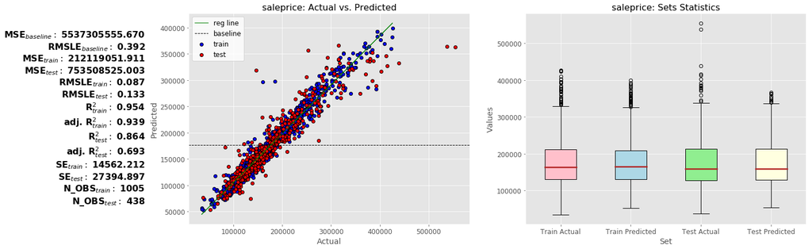

```python
xgb_model2, xgb_model2_summaries=get_model_results(xgb_model2,y_train,X_train, y_test, X_test)
reg_model_results_plots(xgb_model2_summaries)
```

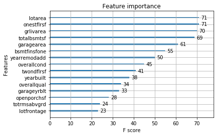

```python
xgb.plot_importance(xgb_model2,max_num_features=15)
plt.show()
```

The results are not better at all after optimization. This is also why we didn't explore the GridSearch further, as it is a very exhausting (in terms of computation) approach, which doesn't give us the improvement that we would have liked

### Another model using the "train"-method

```python
xg_reg2 = xgb.train(params=params, dtrain=data_dmatrix, num_boost_round=10)
```

[output not shown]

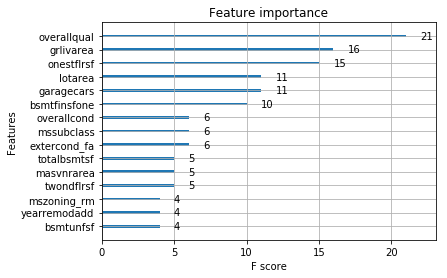

```python
xgb.plot_importance(xg_reg2,max_num_features=15)
plt.rcParams['figure.figsize'] = [5, 5]
plt.show()
```

## Summary

Out of the models we have built, the XG Boosted Regression yields the best/lowest RMSLE and a somewhat high (adjusted) R²Score. It also provides a mean to find out about the Feature Importance, which is very useful, if one needs to find out about the contribution of each attribute towards the target variable.

Overall, all concepts provide similar results regarding the important features, which is also a confirmation that we picked up the correct features and it is not by chance. Further methods that could have been used to adjust the models are e.g. forward and backward eliminations, RFE to reduce the number of attributes and find out which attributes are not important at all. Features like OverallQual, GrLivAre, LotArea were appearing again and again in various models and also in the EDA, which means first the Features are really confirmed as important and second, that the EDA gave us a pretty good impression of what is really important. Another approach would be to use the identified attributes, along with some subject expertise to choose the important feetures and build a model with those. As we could already confirm some of the attributes, it was proven that this approach would be legitimate.

In our view, we preferred the options of sklearn a little bit more than from statsmodels. It provides additional functions and possibilites to tweak the models, e.g. using RFE, GridSearch. Overall statistical Methods like OLS and Lasso Regression are a bit easier to interpret.

Even though we didn't quite reach the Leaderboard, our results weren't too bad! With some more time and tweaking, we would definitely have been able to improve more and use some other approach (like the one mentioned above) and some other models.